# Factor

Humoon

2022-03-22

## 原生 R 环境处理 factor

### R 中储存 factor 的步骤

1. 建立 levels 与整数的映射关系
2. 按照映射关系，将 factor 转换为整数向量存储

### levels 的排序

1. 默认按字母顺序排序

```r
class <- factor(c("Poor", "Improved", "Excellent"), ordered = T)
class
```

```
#> [1] Poor      Improved  Excellent
#> Levels: Excellent < Improved < Poor
```

2. 通过 levels 参数人工设定因子型数据各水平的顺序

```r
class <- factor(
  c("Poor", "Improved", "Excellent"),
  levels = c("Poor", "Improved", "Excellent"),
  ordered = T
)
class
```

```
#> [1] Poor      Improved  Excellent
#> Levels: Poor < Improved < Excellent
```

3. 与 levels 出现的顺序保持一致

在创建因子时，将水平设置为`unique(x)`；或者在创建因子后再对其使用`fct_inorder()`函数，需要forcats包（包含在tidyverse全家桶中）。

```r
x <- c("A", "T", "T", "A", "C", "K")
y <- factor(x, levels = unique(x))
y
```

```
#> [1] A T T A C K
#> Levels: A T C K
```

```r
x %>%
  factor() %>%
  fct_inorder()
```

```
#> [1] A T T A C K
#> Levels: A T C K
```

## 使用forcats处理factor

想要**以非字母表顺序显示字符串向量时（如一个轴为离散变量的绘图），就需要用到因子**。forcats 包中含有大量处理因子的函数。

当字符串向量中有很多重复元素时，用 factor （本质是整数）储存比用字符串节省空间。因此，R 基础包中的很多函数都自动将字符串转换为因子。这意味着因子经常出现在并不真正适合它们的地方。好在不用担心 tidyverse 中会出现这种问题。

```r
library(forcats)
```

### 创建因子

要想创建一个因子，必须先创建 levels 向量：

```r
month_levels <- c(
  "Jan", "Feb", "Mar", "Apr", "May", "Jun",
  "Jul", "Aug", "Sep", "Oct", "Nov", "Dec"
)
```

### 因子的排序

#### 生成因子时的顺序

```r
## 非因子的排序遵循字母表排序
x1 <- c("Dec", "Apr", "Jan", "Mar", "Mar", "Apr")
x1
```

```
#> [1] "Dec" "Apr" "Jan" "Mar" "Mar" "Apr"
```

```r
sort(x1)
```

```
#> [1] "Apr" "Apr" "Dec" "Jan" "Mar" "Mar"
```

```r
## 因子：按预先声明的因子顺序排序
y1 <- factor(x1, levels = month_levels)
sort(y1)
```

```
#> [1] Jan Mar Mar Apr Apr Dec
#> Levels: Jan Feb Mar Apr May Jun Jul Aug Sep Oct Nov Dec
```

```r
## 因子：字母表排序
y2 <- factor(x1) # 如果省略了定义水平的这个步骤直接创建因子
sort(y2) # 会按字母顺序排序
```

```
#> [1] Apr Apr Dec Jan Mar Mar
#> Levels: Apr Dec Jan Mar
```

```r
## 因子：以初始数据的出现顺序作为默认排序
# 令levels参数为unique(x)，或在创建因子后使用fct_inorder()函数
y3 <- factor(x1, levels = unique(x1))
sort(y3)
```

```
#> [1] Dec Apr Apr Jan Mar Mar
#> Levels: Dec Apr Jan Mar
```

```r
y4 <- factor(x1) %>% fct_inorder()
sort(y4)
```

```
#> [1] Dec Apr Apr Jan Mar Mar
#> Levels: Dec Apr Jan Mar
```

#### `fct_relevel()`

随时重新手动设定顺序

```r
income <- c("low", "high", "medium", "medium", "low", "high", "high")
x <- factor(income)
x %>% fct_relevel(levels = c("high", "medium", "low"))
```

```
#> [1] low    high   medium medium low    high   high
#> Levels: high medium low
```

```r
x %>% fct_relevel(levels = c("medium"))
```

```
#> [1] low    high   medium medium low    high   high
#> Levels: medium high low
```

```r
x %>% fct_relevel("medium", after = Inf)
```

```
#> [1] low    high   medium medium low    high   high
#> Levels: high low medium
```

#### `fct_rev()`

对因子逆序

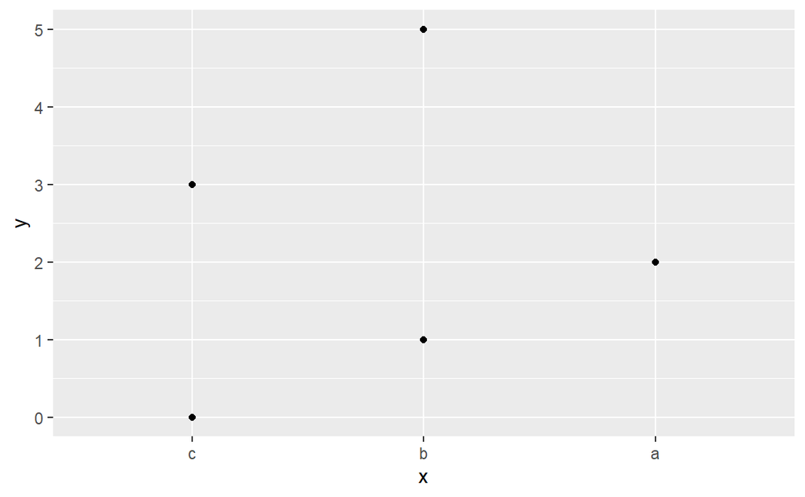

```r
d <- tibble(
  x = c("a", "a", "b", "b", "c", "c"),
  y = c(2, 2, 1, 5, 0, 3)
)

d %>%
  mutate(x = fct_rev(x)) %>%
  ggplot(aes(x = x, y = y)) +
  geom_point()
```